```python
import pandas as pd
import matplotlib.pyplot as plt
import seaborn as sns
```

```python
studenti = pd.read_csv ("Students.csv")
```

# Dataset o studentima i njihovom uspjehu na ispitima

## želite otkriti postoje li neki zanimjivi klusteri (grupe) unutar ove populacije

## Što bi moglo utjecati na uspjeh studenata na ispitima

```python
studenti.head()
```

|  | gender | race/ethnicity | parental level of education | lunch | test preparation course | math score | reading score | writing score |
| --- | --- | --- | --- | --- | --- | --- | --- | --- |
| 0 | female | group B | bachelor's degree | standard | none | 72 | 72 | 74 |
| 1 | female | group C | some college | standard | completed | 69 | 90 | 88 |
| 2 | female | group B | master's degree | standard | none | 90 | 95 | 93 |
| 3 | male | group A | associate's degree | free/reduced | none | 47 | 57 | 44 |
| 4 | male | group C | some college | standard | none | 76 | 78 | 75 |

# EDA analiza

## eksplorativna analiza, što znači da dubinski istražujete, koji put ponavljate analizu s drugim varijablama, vrtite se u krug dok ne pronadjete odgovore

## Koji put ne pornadjete nikakve odgovore jer su podaci jednostavno loši

# **Zadatak 1**

## Zašto su podaci o rasi / etnicitetu anonimizirani?

```python
studenti.describe ()
```

|  | math score | reading score | writing score |
| --- | --- | --- | --- |
| count | 1000.00000 | 1000.000000 | 1000.000000 |
| mean | 66.08900 | 69.169000 | 68.054000 |
| std | 15.16308 | 14.600192 | 15.195657 |
| min | 0.00000 | 17.000000 | 10.000000 |
| 25% | 57.00000 | 59.000000 | 57.750000 |
| 50% | 66.00000 | 70.000000 | 69.000000 |
| 75% | 77.00000 | 79.000000 | 79.000000 |
| max | 100.00000 | 100.000000 | 100.000000 |

```python
studenti.corr(numeric_only = True)
```

|  | math score | reading score | writing score |
| --- | --- | --- | --- |
| math score | 1.000000 | 0.817580 | 0.802642 |
| reading score | 0.817580 | 1.000000 | 0.954598 |
| writing score | 0.802642 | 0.954598 | 1.000000 |

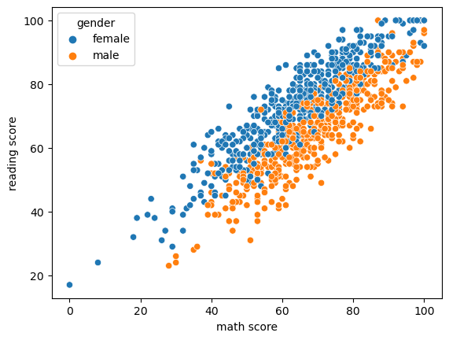

```python
sns.scatterplot (data = studenti, x = "math score", y = "reading score", hue = "gender")
```

```python
studenti.gender.value_counts()
```

```
gender
female    518
male      482
Name: count, dtype: int64
```

```python
studenti["race/ethnicity"].value_counts()
```

```
race/ethnicity
group C    319
group D    262
group B    190
group E    140
group A     89
Name: count, dtype: int64
```

### paziti na gornjem primjeru! Morali smo staviti uglate zagrade i bez točke jer immao naziv varijable race/ethnicity

```python
studenti.lunch.value_counts()
```

```
lunch
standard        645
free/reduced    355
Name: count, dtype: int64
```

```python
studenti["parental level of education"].value_counts()
```

```
parental level of education
some college          226
associate's degree    222
high school           196
some high school      179
bachelor's degree     118
master's degree        59
Name: count, dtype: int64
```

```python
studenti["test preparation course"].value_counts()
```

```
test preparation course
none         642
completed    358
Name: count, dtype: int64
```

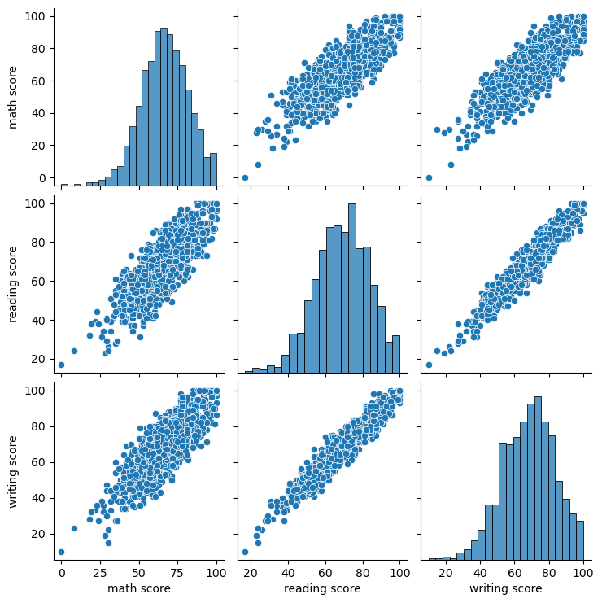

```python
sns.pairplot (studenti)
```

```python
studenti.head()
```

|  | gender | race/ethnicity | parental level of education | lunch | test preparation course | math score | reading score | writing score |
| --- | --- | --- | --- | --- | --- | --- | --- | --- |
| 0 | female | group B | bachelor's degree | standard | none | 72 | 72 | 74 |
| 1 | female | group C | some college | standard | completed | 69 | 90 | 88 |
| 2 | female | group B | master's degree | standard | none | 90 | 95 | 93 |
| 3 | male | group A | associate's degree | free/reduced | none | 47 | 57 | 44 |
| 4 | male | group C | some college | standard | none | 76 | 78 | 75 |

# Brainstroming session - nema krivog odgovora, istražujemo!

## Kad bi išli grupirati podatke, koji kategorički podati (stringovi) mogu utjecati na uspjeh studenata na ispitima?

```python
studenti_spol = studenti.groupby ("gender")
```

```python
studenti_spol ["math score"].mean()
```

```
gender
female    63.633205
male      68.728216
Name: math score, dtype: float64
```

```python
studenti_spol [["math score", "reading score", "writing score"]].mean()
```

| gender | math score | reading score | writing score |
| --- | --- | --- | --- |
| female | 63.633205 | 72.608108 | 72.467181 |
| male | 68.728216 | 65.473029 | 63.311203 |

```python
studenti_spol ["lunch"].value_counts()
```

```
gender  lunch
female  standard        329
        free/reduced    189
male    standard        316
        free/reduced    166
Name: count, dtype: int64
```

# idemo grupirati po više varijabli

```python
studenti_rasa_roditelji = studenti.groupby (["race/ethnicity", "parental level of education"])
```

```python
studenti_rasa_roditelji ["math score"].mean()
```

```
race/ethnicity  parental level of education
group A         associate's degree             61.000000
                bachelor's degree              67.166667
                high school                    60.444444
                master's degree                57.666667
                some college                   63.888889
                some high school               58.916667
group B         associate's degree             66.097561
                bachelor's degree              69.300000
                high school                    59.791667
                master's degree                67.166667
                some college                   63.189189
                some high school               61.815789
group C         associate's degree             66.730769
                bachelor's degree              68.150000
                high school                    60.906250
                master's degree                67.052632
                some college                   65.130435
                some high school               60.551020
group D         associate's degree             67.600000
                bachelor's degree              67.571429
                high school                    62.863636
                master's degree                72.521739
                some college                   68.731343
                some high school               66.760000
group E         associate's degree             74.897436
                bachelor's degree              76.555556
                high school                    70.772727
                master's degree                74.625000
                some college                   73.828571
                some high school               72.111111
Name: math score, dtype: float64
```

```python
titanik = pd.read_csv ("titanic.csv")
```

# Titanik dataset

## Opet ćemo napraviti analizu, iz prošlih analiza se sjećamo da je razred putovanja utjecao na stopu preživljavanja. Putnici iz prvog razreda te žene i djeca su imali veću šansu za preživljavanje

```python
titanik.head()
```

|  | Survived | Pclass | Name | Sex | Age | Siblings/Spouses Aboard | Parents/Children Aboard | Fare |
| --- | --- | --- | --- | --- | --- | --- | --- | --- |
| 0 | 0 | 3 | Mr. Owen Harris Braund | male | 22.0 | 1 | 0 | 7.2500 |
| 1 | 1 | 1 | Mrs. John Bradley (Florence Briggs Thayer) Cum... | female | 38.0 | 1 | 0 | 71.2833 |
| 2 | 1 | 3 | Miss. Laina Heikkinen | female | 26.0 | 0 | 0 | 7.9250 |
| 3 | 1 | 1 | Mrs. Jacques Heath (Lily May Peel) Futrelle | female | 35.0 | 1 | 0 | 53.1000 |
| 4 | 0 | 3 | Mr. William Henry Allen | male | 35.0 | 0 | 0 | 8.0500 |

```python
titanik.describe()
```

|  | Survived | Pclass | Age | Siblings/Spouses Aboard | Parents/Children Aboard | Fare |
| --- | --- | --- | --- | --- | --- | --- |
| count | 887.000000 | 887.000000 | 887.000000 | 887.000000 | 887.000000 | 887.00000 |
| mean | 0.385569 | 2.305524 | 29.471443 | 0.525366 | 0.383315 | 32.30542 |
| std | 0.487004 | 0.836662 | 14.121908 | 1.104669 | 0.807466 | 49.78204 |
| min | 0.000000 | 1.000000 | 0.420000 | 0.000000 | 0.000000 | 0.00000 |
| 25% | 0.000000 | 2.000000 | 20.250000 | 0.000000 | 0.000000 | 7.92500 |
| 50% | 0.000000 | 3.000000 | 28.000000 | 0.000000 | 0.000000 | 14.45420 |
| 75% | 1.000000 | 3.000000 | 38.000000 | 1.000000 | 0.000000 | 31.13750 |
| max | 1.000000 | 3.000000 | 80.000000 | 8.000000 | 6.000000 | 512.32920 |

```python
titanik.corr(numeric_only = True)
```

|  | Survived | Pclass | Age | Siblings/Spouses Aboard | Parents/Children Aboard | Fare |
| --- | --- | --- | --- | --- | --- | --- |
| Survived | 1.000000 | -0.336528 | -0.059665 | -0.037082 | 0.080097 | 0.256179 |
| Pclass | -0.336528 | 1.000000 | -0.391492 | 0.085026 | 0.020252 | -0.548919 |
| Age | -0.059665 | -0.391492 | 1.000000 | -0.297669 | -0.193741 | 0.112329 |
| Siblings/Spouses Aboard | -0.037082 | 0.085026 | -0.297669 | 1.000000 | 0.414244 | 0.158839 |
| Parents/Children Aboard | 0.080097 | 0.020252 | -0.193741 | 0.414244 | 1.000000 | 0.215470 |
| Fare | 0.256179 | -0.548919 | 0.112329 | 0.158839 | 0.215470 | 1.000000 |

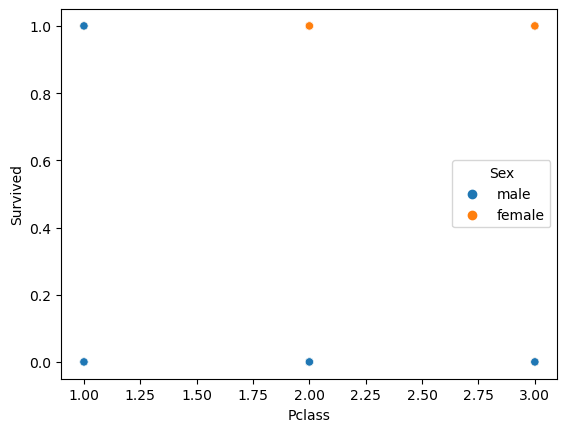

```python
sns.scatterplot (data = titanik, x = "Pclass", y = "Survived", hue = "Sex")
```